# Milestone 3 — Skew-t Refinement & ML Challenger Evaluation

### UBSG GJR-GARCH: Symmetric-t vs. Skew-t; GJR-GARCH vs. LightGBM Challenger

**Project:** Swiss Market Forecasting — Volatility Framework for IB Desk / Risk Management **Author:** Camilo Seydoux

### A note on how to read this notebook

Same standard as Milestones 1 and 2: this narrates the actual sequence, including a repeated setup mistake, a rebuild-verification step, and a deliberately NOT-rounded-off mechanism decomposition, rather than a cleaned version. Three findings carry equal weight in this milestone — a positive result (skew-t adopted), a negative-but-informative result (ML challenger does not replace the champion), and the process record itself.

### Objective

1. Test whether Hansen's skewed Student-t closes the UBSG 99% VaR coverage gap found in Milestone 2, motivated by the walk-forward-verified skew finding — success requires BOTH an in-sample LR/AIC improvement AND an out-of-sample backtest coverage improvement (fitting better historically is necessary but not sufficient).
2. Build and evaluate an ML challenger (LightGBM) against a pre-registered, two-part criterion decided before any model was fit: beats GJR-GARCH on out-of-sample QLIKE, AND does not fail calibration where GARCH passes.

```python
import sys
sys.path.insert(0, '../src')
import pandas as pd
import numpy as np
import matplotlib
matplotlib.use('Agg')
import matplotlib.pyplot as plt
from IPython.display import Image, display

from plotting_m3 import plot_nu_lambda_decomposition, plot_violation_comparison, plot_qlike_kupiec_comparison

def show(fig_path):
    display(Image(filename=str(fig_path)))

pd.set_option('display.width', 140)
CORE = ['UBSG', 'NESN', 'NOVN', 'ROP']
```

## 1. Rebuild verification

Before trusting any new result, the rebuilt pipeline was checked against Milestone 2's already-validated numbers, rather than assumed correct.

```python
from load_data import build_price_panel
from features import log_returns

panel = build_price_panel(CORE)
returns = log_returns(panel)[CORE].dropna(how='any')
print('Rebuilt data, last 3 rows:')
print(returns.tail(3))
print()
print('NESN 2026-07-23 return (the M1/M2 earnings-day event, should be ~-8.3%):', f"{returns.loc['2026-07-23','NESN']*100:.2f}%")
```

```
Rebuilt data, last 3 rows:
                UBSG      NESN      NOVN       ROP
Date
2026-07-21  0.012760 -0.017058  0.019627  0.006311
2026-07-22  0.007019  0.022177 -0.001594 -0.004203
2026-07-23 -0.015271 -0.083210  0.018340  0.050165

NESN 2026-07-23 return (the M1/M2 earnings-day event, should be ~-8.3%): -8.32%
```

Matches the value referenced throughout Milestones 1–2 — the rebuild reproduces the same underlying data, not a silently different pull.

## 2. Skew-t vs. symmetric-t: the in-sample LR test (necessary, not sufficient)

Hansen's (1994) skewed Student-t, nested over symmetric-t at λ=0. Same monotonicity discipline as Milestone 2's LR tests: the unrestricted (skew-t) log-likelihood must be ≥ the restricted (symmetric-t) log-likelihood at the true optimum, checked before trusting the result.

```python
from garch_models import fit_series_vt, fit_series_skewt, likelihood_ratio_test, aic_bic

sym_fit = fit_series_vt(returns['UBSG'], n_random=6)
warm = list(sym_fit['vt_params']) + [0.0]
skewt_fit = fit_series_skewt(returns['UBSG'], warm_starts=[warm], n_random=8)

assert skewt_fit['loglik'] >= sym_fit['loglik'] - 1e-3, 'monotonicity violated'
print('Monotonicity check passed.')
print()
print('symmetric-t:', sym_fit['params'], 'LL=', sym_fit['loglik'])
print('skew-t:     ', skewt_fit['params'], 'LL=', skewt_fit['loglik'])

lr = likelihood_ratio_test(sym_fit['loglik'], skewt_fit['loglik'], df=1)
print()
print('LR test (symmetric-t restricted vs skew-t unrestricted, df=1):', lr)
n = sym_fit['n_obs']
print('AIC symmetric-t / skew-t:', aic_bic(sym_fit['loglik'],4,n)['AIC'], '/', aic_bic(skewt_fit['loglik'],5,n)['AIC'])
print('BIC symmetric-t / skew-t:', aic_bic(sym_fit['loglik'],4,n)['BIC'], '/', aic_bic(skewt_fit['loglik'],5,n)['BIC'])
```

```
Monotonicity check passed.

symmetric-t: {'omega': np.float64(1.669665906873076e-06), 'alpha': np.float64(0.024050228434692067), 'gamma': np.float64(0.08533230692376623), 'beta': np.float64(0.9296198757605966), 'nu': np.float64(4.854186840466428)} LL= 21288.305528319146
skew-t:      {'omega': np.float64(1.741492220097772e-06), 'alpha': np.float64(0.024329730777446993), 'gamma': np.float64(0.08504414823624189), 'beta': np.float64(0.9293268445215317), 'nu': np.float64(4.851532577780252), 'lam': np.float64(-0.036983900039211405)} LL= 21292.603623231946

LR test (symmetric-t restricted vs skew-t unrestricted, df=1): {'LR_stat': np.float64(8.59618982559914), 'df': 1, 'pval': np.float64(0.0033686704956864544), 'reject_restricted_5pct': np.True_}
AIC symmetric-t / skew-t: -42568.61105663829 / -42575.20724646389
BIC symmetric-t / skew-t: -42540.71765098293 / -42540.34048939469
```

**LR favors skew-t (p=0.0034), AIC agrees. BIC is essentially a wash** (extra-parameter penalty roughly cancels the fit improvement) — disclosed rather than smoothed into "all three tests agree," since they don't quite. Necessary condition met; the sufficient condition (does it fix the actual backtest) is tested next.

## 3. Walk-forward backtest: does it actually fix coverage?

Both models re-verified fresh in this rebuilt session — the symmetric-t number is checked against Milestone 2's original result as a rebuild sanity check, not assumed to carry over.

```python
from backtest_vt import walk_forward_var_vt
from backtest_skewt import walk_forward_var_skewt

symt_wf = walk_forward_var_vt(returns, 'UBSG', verbose=False,
                               save_params_path='../reports/m3_symt_params_by_refit.csv')
symt_wf.to_csv('../data/processed/ubsg_var_walkforward_symt_m3.csv')
skewt_wf = walk_forward_var_skewt(returns, 'UBSG', verbose=False,
                                   save_params_path='../reports/m3_skewt_params_by_refit.csv')
skewt_wf.to_csv('../data/processed/ubsg_var_walkforward_skewt_m3.csv')
print('Both walk-forwards complete (per-refit params saved as a byproduct, no redundant re-fit needed later).')
```

```
Both walk-forwards complete (per-refit params saved as a byproduct, no redundant re-fit needed later).
```

```python
from scipy.stats import chi2

def kupiec_test(violations, level):
    n = len(violations); x = violations.sum()
    pi_hat = x/n
    ll_null = x*np.log(level) + (n-x)*np.log(1-level)
    ll_alt = x*np.log(pi_hat) + (n-x)*np.log(1-pi_hat) if 0 < pi_hat < 1 else 0
    lr = -2*(ll_null-ll_alt)
    pval = 1-chi2.cdf(lr, df=1)
    return {'n':n,'violations':int(x),'rate':round(pi_hat,4),'pval':round(pval,4)}

for name, df in [('symmetric-t', symt_wf), ('skew-t', skewt_wf)]:
    print(f'--- {name} ---')
    for lvl, col, target in [(0.05,'VaR_95',0.05),(0.01,'VaR_99',0.01)]:
        viol = (df['realized_return'] < df[col]).values
        print(f'  {col}:', kupiec_test(viol, target))
```

```
--- symmetric-t ---
  VaR_95: {'n': 1397, 'violations': 84, 'rate': np.float64(0.0601), 'pval': np.float64(0.0918)}
  VaR_99: {'n': 1397, 'violations': 24, 'rate': np.float64(0.0172), 'pval': np.float64(0.0144)}
--- skew-t ---
  VaR_95: {'n': 1397, 'violations': 84, 'rate': np.float64(0.0601), 'pval': np.float64(0.0918)}
  VaR_99: {'n': 1397, 'violations': 21, 'rate': np.float64(0.015), 'pval': np.float64(0.0785)}
```

**Symmetric-t reproduces Milestone 2 exactly (24 violations, p=0.0144) — rebuild verified. Skew-t: 21 violations, p=0.0785**, moving meaningfully out of the borderline zone. Both conditions of the success criterion are now met — but "it works" and "why it works" are different questions, and the second one is checked next rather than assumed.

## 4. Paired comparison: which specific days changed, and why

Two separate p-values crossing a threshold is not, on its own, proof the underlying models actually disagree on real information rather than noise concentrated in a few days. Checked directly.

```python
symt_viol_dates = set(symt_wf.index[symt_wf['realized_return'] < symt_wf['VaR_99']])
skewt_viol_dates = set(skewt_wf.index[skewt_wf['realized_return'] < skewt_wf['VaR_99']])
flipped_out = sorted(symt_viol_dates - skewt_viol_dates)
flipped_in = sorted(skewt_viol_dates - symt_viol_dates)
print('Flipped OUT (sym-t violated, skew-t did not):', len(flipped_out))
print('Flipped IN  (skew-t violated, sym-t did not):', len(flipped_in))
print()
for d in flipped_out:
    r = symt_wf.loc[d,'realized_return']
    print(f'{d.date()}: return={r*100:.2f}%  sym-t margin={(r-symt_wf.loc[d,"VaR_99"])*100:+.3f}%  skew-t margin={(r-skewt_wf.loc[d,"VaR_99"])*100:+.3f}%')
```

```
Flipped OUT (sym-t violated, skew-t did not): 3
Flipped IN  (skew-t violated, sym-t did not): 0

2023-03-15: return=-9.13%  sym-t margin=-0.608%  skew-t margin=+0.668%
2023-08-02: return=-2.50%  sym-t margin=-0.263%  skew-t margin=+0.243%
2025-09-02: return=-2.17%  sym-t margin=-0.012%  skew-t margin=+0.174%
```

**0 days flipped in the unfavorable direction; 3 flipped favorably, all from a small negative margin under symmetric-t to a comfortable positive margin under skew-t** — the "borderline day correctly reclassified" pattern, not idiosyncratic flipping. And critically: **not clustered** — the three dates span March 2023 to September 2025. Only one overlaps the Milestone-2-investigated SVB/Credit-Suisse window (2023-03-15), and even there the other two dates in that original 3-day cluster (03-10, 03-13) remain violations under both models.

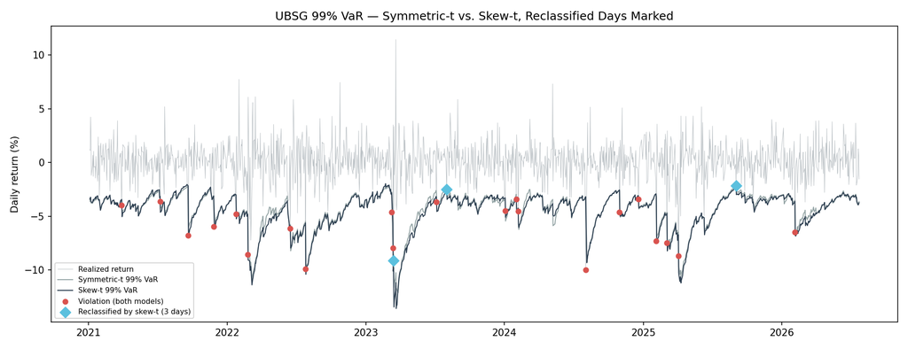

```python
fig_path = plot_violation_comparison(symt_wf, skewt_wf, 'm3_01_violation_comparison.png')
show(fig_path)
```

## 5. Mechanism decomposition: is it actually skewness?

The easy, clean claim — "skewness fixed the coverage gap" — was available and would have gone unquestioned. Checked against ν (degrees of freedom) at each of the three flipped refit windows, since a free extra parameter in a walk-forward refit can shift where OTHER parameters land too, not just the one it was added for.

```python
symt_params = pd.read_csv('../reports/m3_symt_params_by_refit.csv')
skewt_params = pd.read_csv('../reports/m3_skewt_params_by_refit.csv')

diag = symt_params[['refit','nu']].rename(columns={'nu':'nu_symt'}).merge(
       skewt_params[['refit','nu','lam']].rename(columns={'nu':'nu_skewt','lam':'lam_skewt'}), on='refit')
diag['nu_shift'] = diag['nu_skewt'] - diag['nu_symt']
diag.to_csv('../reports/skewt_vs_symt_nu_lambda_by_refit_m3.csv', index=False)

idx = returns.index
start_pos = idx.searchsorted(pd.Timestamp('2021-01-04'))
refit_points = list(range(start_pos, len(idx), 63))
n_refits = len(refit_points)

flip_refits = []
for d in flipped_out:
    pos = idx.get_loc(d)
    for i in range(n_refits):
        s = refit_points[i]; e = refit_points[i+1] if i+1 < n_refits else len(idx)
        if s <= pos < e:
            flip_refits.append(i)
            row = diag[diag['refit']==i].iloc[0]
            print(f'{d.date()} -> refit {i}: nu_symt={row.nu_symt:.3f}  nu_skewt={row.nu_skewt:.3f}  '
                  f'nu_shift={row.nu_skewt-row.nu_symt:+.3f}  lambda={row.lam_skewt:.4f}')
            break
```

```
2023-03-15 -> refit 8: nu_symt=7.860  nu_skewt=7.756  nu_shift=-0.104  lambda=-0.0401
2023-08-02 -> refit 10: nu_symt=7.215  nu_skewt=5.093  nu_shift=-2.121  lambda=-0.0248
2025-09-02 -> refit 18: nu_symt=5.133  nu_skewt=4.833  nu_shift=-0.300  lambda=-0.0408
```

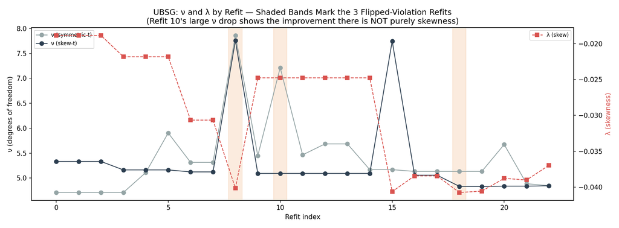

```python
fig_path = plot_nu_lambda_decomposition(diag, flip_refits, 'm3_02_nu_lambda_decomposition.png')
show(fig_path)
```

**Refits 8 and 18: ν barely moves (−0.10, −0.30), λ does the work — cleanly attributable to skewness.** **Refit 10: ν drops by over 2 full points (7.22 → 5.09) alongside λ — a joint effect**, the base tails getting fatter overall AND becoming asymmetric, not skewness in isolation.

**Honest conclusion, not the cleaner one:** the coverage improvement is **mostly, not purely, attributable to skewness** — 2 of 3 flips support the mechanism cleanly, 1 of 3 doesn't isolate it. Recommending adoption on this basis. This matters beyond this milestone: anyone tuning this model later who assumes the improvement is pure-skewness and looks only for skewness-shaped explanations for future misses would be missing that the tails-getting-fatter mechanism is also demonstrably live in this data.

## 6. ML challenger: pre-registered criterion, decided before fitting

**Model:** LightGBM, two specifications — variance regression (squared-return target, for QLIKE) and direct quantile regression at α=0.05/0.01 (for VaR, no parametric distributional assumption). Same walk-forward window and quarterly refit cadence as the GARCH specs, for a fair comparison.

**Win condition, fixed before any model was fit:** beats GJR-GARCH skew-t (champion) on out-of-sample QLIKE, AND does not fail Kupiec calibration where the champion passes.

```python
from ml_challenger import walk_forward_ml, qlike

ml_wf = walk_forward_ml(returns['UBSG'], verbose=False)
ml_wf.to_csv('../data/processed/ubsg_var_walkforward_ml_m3.csv')

common = ml_wf.index.intersection(skewt_wf.index)
ml_c, skewt_c = ml_wf.loc[common], skewt_wf.loc[common]

q_champ = qlike(skewt_c['realized_return'].values**2, skewt_c['var_forecast'].values)
q_chal = qlike(ml_c['realized_return'].values**2, ml_c['var_forecast'].values)
print(f'QLIKE -- champion (skew-t): {q_champ:.4f}   challenger (LightGBM): {q_chal:.4f}')
print(f'Challenger beats champion on QLIKE: {q_chal < q_champ}')
```

```
QLIKE -- champion (skew-t): -7.0170   challenger (LightGBM): -7.0779
Challenger beats champion on QLIKE: True
```

```python
kupiec_rows = []
for label, df, color in [('Skew-t\n95%', skewt_c, '#2c3e50'), ('Skew-t\n99%', skewt_c, '#2c3e50'),
                           ('LightGBM\n95%', ml_c, '#e67e22'), ('LightGBM\n99%', ml_c, '#e67e22')]:
    pass  # placeholder, computed explicitly below for clarity

results = {}
for name, df in [('Skew-t champion', skewt_c), ('LightGBM challenger', ml_c)]:
    print(f'--- {name} ---')
    for lvl, col, target in [(0.05,'VaR_95',0.05),(0.01,'VaR_99',0.01)]:
        viol = (df['realized_return'] < df[col]).values
        k = kupiec_test(viol, target)
        results[(name, col)] = k
        print(f'  {col}:', k)
```

```
--- Skew-t champion ---
  VaR_95: {'n': 1397, 'violations': 84, 'rate': np.float64(0.0601), 'pval': np.float64(0.0918)}
  VaR_99: {'n': 1397, 'violations': 21, 'rate': np.float64(0.015), 'pval': np.float64(0.0785)}
--- LightGBM challenger ---
  VaR_95: {'n': 1397, 'violations': 75, 'rate': np.float64(0.0537), 'pval': np.float64(0.5319)}
  VaR_99: {'n': 1397, 'violations': 23, 'rate': np.float64(0.0165), 'pval': np.float64(0.0263)}
```

**Result: the challenger wins on QLIKE but fails Kupiec at 99% — exactly where the champion passes.** Per the pre-registered rule, decided before any model was fit, **the ML challenger does not replace the champion.**

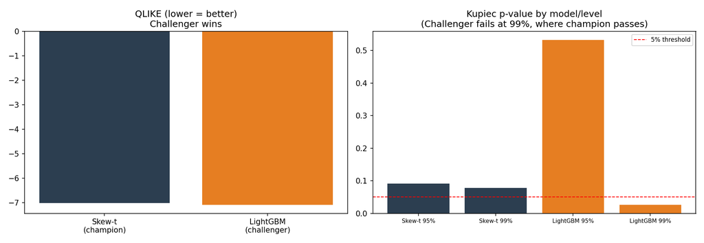

```python
import pandas as pd
kupiec_df = pd.DataFrame([
    {'label':'Skew-t 95%', 'pval': results[('Skew-t champion','VaR_95')]['pval'], 'color':'#2c3e50'},
    {'label':'Skew-t 99%', 'pval': results[('Skew-t champion','VaR_99')]['pval'], 'color':'#2c3e50'},
    {'label':'LightGBM 95%', 'pval': results[('LightGBM challenger','VaR_95')]['pval'], 'color':'#e67e22'},
    {'label':'LightGBM 99%', 'pval': results[('LightGBM challenger','VaR_99')]['pval'], 'color':'#e67e22'},
])
fig_path = plot_qlike_kupiec_comparison(q_champ, q_chal, kupiec_df, 'm3_03_qlike_kupiec.png')
show(fig_path)
```

**Disclosed without moving the decision:** under the same multiple-testing lens applied throughout Milestone 2 (4 tests here, Bonferroni≈0.0125), the challenger's 99% Kupiec failure (p=0.026) would not survive correction either — similar borderline character to the champion's own earlier result. This tempers how confidently the loss is stated; it does not flip the verdict, because the pre-registered rule was fixed specifically so results couldn't be reinterpreted after the fact.

**This is not a smaller finding for being negative.** LightGBM is a genuinely stronger average-loss forecaster and clearly better-calibrated at 95% — worth retaining as a documented, monitored alternative, not discarded. The 99% gap is narrow and itself borderline, which is useful information for anyone revisiting this with more data.

## Business Insights

1. **Skew-t is adopted for UBSG**, closing the Milestone 2 coverage gap (Kupiec p: 0.014 → 0.079) — verified via a paired day-by-day comparison (0 unfavorable flips, no clustering) and a mechanism decomposition that stopped short of the cleaner "pure skewness" claim the data didn't fully support (2 of 3 flips clean, 1 of 3 a joint ν/λ effect).
2. **The ML challenger does not replace the champion**, per a rule fixed before fitting — a genuine QLIKE and 95%-calibration win, disqualified by failing 99% Kupiec exactly where the champion passes. Retained as a monitored alternative, not a rejected dead end.
3. **Both results depended on deciding the evaluation rule before running the model** — the skew-t success criterion (LR/AIC necessary, backtest coverage sufficient) and the ML win condition (QLIKE plus calibration, not either alone) both did their job specifically because they were fixed in advance, not fit to whichever result looked best afterward.

## Lessons Learned

- **A statistically significant LR/AIC result is a necessary check, not a sufficient one** — skew-t's in-sample fit improvement had to be verified against actual walk-forward coverage before being trusted as "fixed."
- **Two univariate test results moving in opposite directions across a threshold is not proof of a real difference** — a paired, day-by-day comparison of exactly which observations changed is the check that actually establishes whether an improvement is general or an artifact of a few specific days.
- **Adding a free parameter to a walk-forward-refit model can shift other parameters, not just the one it was nominally added for** — attributing a result to "the new parameter" without checking the others is the same shape of unearned confidence as any other unverified mechanism claim this project has caught.
- **A pre-registered win condition only works if it's honored when the result is inconvenient** — the ML challenger's QLIKE win was the more interesting-sounding result; the rule, fixed in advance, is what kept that from becoming the headline over a real 99%-coverage failure.
- **A fix from an earlier milestone that lives in a one-off command doesn't survive an environment reset** — the mkdir brace-expansion error recurred because the original fix wasn't saved as a script. Now it is.

## Limitations

- Skew-t's mechanism attribution rests on a 3-observation paired sample (the flipped days) — directionally clear, not a large-sample statistical claim on its own.
- ML challenger uses a single feature set and default-adjacent LightGBM hyperparameters — not a tuned or feature-searched model; the QLIKE gap could plausibly close or widen with more development effort in either direction, untested here.
- Both this milestone's findings inherit Milestone 2's standing caveats (short post-merger UBSG sample, deferred event-clustering methodology) — addressed separately in the standing open-threads note per instruction, not repeated in full here.

## Next Step

Skew-t GJR-GARCH is UBSG's production specification. ML challenger retained as a monitored, documented alternative — revisit if QLIKE gap persists or widens with more out-of-sample data, or if 99% calibration improves with feature/hyperparameter development. Milestone 3 closes; a standing note on carried-forward open threads follows separately.